# Functional analysis

Here we will perform a differential abundance analysis on the gene orthologue groups in order to quantify the functional capacity of different transcriptomes.

## Preprocessing

```r
library(mbtools)

counts <- fread("data/rnaseq/txcounts.csv")
counts[, counts := round(counts)]
counts <- counts[counts > 0]
counts[, sample := tstrsplit(sample, "-")[[3]]]

meta <- fread("data/rnaseq/seq_samples.csv", key = "Sample")
meta[, day := substr(Sample, 4, 6)]
meta[, mouse := substr(Sample, 1, 2)]
meta[, "timepoint_cat" := "before"]
meta[day >= 27, "timepoint_cat" := "during"]
meta
```

| Sample ID | Sample | RIN | concentration [ng/ul] | abundance [ng] | Comments | type | day | mouse | timepoint_cat |
| --- | --- | --- | --- | --- | --- | --- | --- | --- | --- |
| 21 | A4D20 | 2.2 | 29.6 | 1480 |  | non-responder | 20 | A4 | before |
| 22 | A5D20 | 5.8 | 31.6 | 1580 |  | non-responder | 20 | A5 | before |
| 2 | A5D25 | 1.0 | 12.0 | 600 | RIN could not be measured, set to 1 | non-responder | 25 | A5 | before |
| 10 | A5D29 | 6.8 | 10.0 | 500 |  | non-responder | 29 | A5 | during |
| 25 | A6D20 | 4.7 | 174.0 | 8700 |  | responder | 20 | A6 | before |
| 13 | A6D25 | 2.1 | 12.0 | 600 |  | responder | 25 | A6 | before |
| 26 | A7D20 | 9.3 | 53.8 | 2690 |  | responder | 20 | A7 | before |
| 14 | A7D25 | 9.1 | 40.0 | 2000 |  | responder | 25 | A7 | before |
| 17 | B1D29 | 5.2 | 17.0 | 850 |  | untreated | 29 | B1 | during |
| 18 | B2D29 | 7.2 | 22.0 | 1100 |  | untreated | 29 | B2 | during |

[output cut: 7 more lines]

```r
fig_data <- readRDS("data/fig_data.rds")
```

Now we will load the SEED annotations for the contigs:

```r
anns <- fread("data/rnaseq/transcripts_seed.csv")
anns
```

| superpathway | pathway | subpathway | function | id | query | description |
| --- | --- | --- | --- | --- | --- | --- |
| Virulence, Disease and Defense | Resistance to antibiotics and toxic compounds | Resistance to fluoroquinolones | DNA gyrase subunit A (EC 5.99.1.3) | SS17071 | NODE_2_length_21510_cov_78.919799_g1_i0 | DNA gyrase subunit A (EC 5.99.1.3) |
| Virulence, Disease and Defense | Resistance to antibiotics and toxic compounds | Resistance to fluoroquinolones | DNA gyrase subunit B (EC 5.99.1.3) | SS17072 | NODE_2_length_21510_cov_78.919799_g1_i0 | DNA gyrase subunit B (EC 5.99.1.3) |
| Carbohydrates | Monosaccharides | Xylose utilization | predicted xylose isomerase | SS15299 | NODE_3_length_19236_cov_222.073970_g2_i0 | predicted xylose isomerase |
| unclassified | unclassified | Virulence operon involved in protein synthesis (SSU ribosomal proteins) | Translation elongation factor G | SS21162 | NODE_4_length_18179_cov_217.504631_g3_i0 | Translation elongation factor G |
| Carbohydrates | Monosaccharides | L-rhamnose utilization | Alfa-L-rhamnosidase (EC 3.2.1.40) | SS07505 | NODE_5_length_16256_cov_66.398841_g4_i0 | Alfa-L-rhamnosidase (EC 3.2.1.40) |
| Protein Metabolism | Protein processing and modification | N-linked Glycosylation in Bacteria | Phospholipid-lipopolysaccharide ABC transporter | SS08694 | NODE_7_length_15379_cov_30.298892_g6_i0 | Phospholipid-lipopolysaccharide ABC transporter |
| Experimental Subsystems | unclassified | Transporters In Models | TonB-dependent receptor | SS21074 | NODE_9_length_14413_cov_60.527132_g8_i0 | TonB-dependent receptor |
| Nucleosides and Nucleotides | Purines | Purine conversions | Polyphosphate kinase (EC 2.7.4.1) | SS19775 | NODE_10_length_14383_cov_384.156302_g9_i0 | Polyphosphate kinase (EC 2.7.4.1) |
| Experimental Subsystems | unclassified | Sugar catabolome in Shewanella species | Hypothetical periplasmic glycoside hydrolase, family DUF1680 | SS03665 | NODE_11_length_14383_cov_89.500418_g10_i0 | Hypothetical periplasmic glycoside hydrolase, family DUF1680 |
| Carbohydrates | unclassified | Sugar utilization in Thermotogales | Putative glycosyl hydrolase of unknown function (DUF1680) | SS20141 | NODE_11_length_14383_cov_89.500418_g10_i0 | Putative glycosyl hydrolase of unknown function (DUF1680) |

[output cut: 990 more lines]

..and join the counts with the annotations:

```r
fncounts <- anns[counts, on = c(query = "transcript"), nomatch = 0]
fncounts <- fncounts[, .(description = description[1],
                         counts = sum(counts)),
                     by = c("id", "sample")]
fncounts
```

| id | sample | description | counts |
| --- | --- | --- | --- |
| SS16625 | A6D25 | Butyryl-CoA dehydrogenase (EC 1.3.99.2) | 69 |
| SS17750 | A6D25 | Flagellin protein FlaA | 942 |
| SS18601 | A6D25 | Lipoprotein releasing system transmembrane protein LolC | 20 |
| SS18014 | A6D25 | Glycogen phosphorylase (EC 2.4.1.1) | 111 |
| SS18605 | A6D25 | LmbE-like protein | 1 |
| SS13502 | A6D25 | Sulfur carrier protein adenylyltransferase ThiF | 8 |
| SS08248 | A6D25 | Molybdopterin biosynthesis protein MoeB | 2 |
| SS07027 | A6D25 | Galactose/methyl galactoside ABC transport system, ATP-binding protein MglA (EC 3.6.3.17) | 10 |
| SS16109 | A6D25 | 6-phosphofructokinase (EC 2.7.1.11) | 205 |
| SS20489 | A6D25 | S-adenosylmethionine synthetase (EC 2.5.1.6) | 29 |

[output cut: 990 more lines]

We can check if those are more conserved across samples:

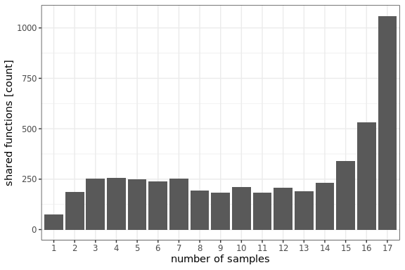

```r
cn_per_id <- fncounts[counts > 0, .N, by = id]
ggplot(cn_per_id, aes(x = factor(N))) + geom_bar() +
  labs(x = "number of samples", y = "shared functions [count]") + theme_bw()
```

```r
ggsave("figures/function_counts.svg", width = 6, height = 4)
```

## Count matrix

First, we will transform the counts to matrix.

```r
count_mat <- dcast(fncounts, id ~ sample, fill = 0)
nm <- count_mat[, id]
count_mat[, id := NULL]
count_mat <- as.matrix(count_mat)
rownames(count_mat) <- nm
dim(count_mat)
```

```
[1] 4847   17
```

We will also filter low abundance transcripts from the count matrix.

```r
count_mat <- t(filter_counts(t(count_mat), abundance = 10, presence = 0.25))
nrow(count_mat)
```

```
[1] 3254
```

Let’s visualize the samples in the functional space.

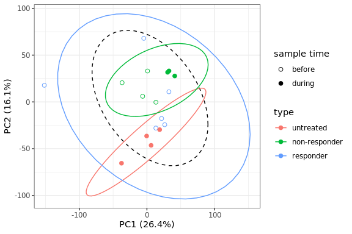

```r
pca <- prcomp(log2(mbtools::normalize(t(count_mat)) + 0.5))
explained <- pca$sdev^2 / sum(pca$sdev^2)
red <- as.data.table(pca$x)
red[, sample := rownames(pca$x)]
red <- meta[red, on = c(Sample = "sample")]
red[, "type" := factor(type, c("untreated", "non-responder", "responder"))]
ggplot(red, aes(x = PC1, y = PC2, color = type, shape=timepoint_cat)) + geom_point(size = 2) +
  labs(x = sprintf("PC1 (%.1f%%)", explained[1] * 100),
       y = sprintf("PC2 (%.1f%%)", explained[2] * 100),
       shape = "sample time") +
  stat_ellipse(data = red[timepoint_cat == "before"], color="black", lty="dashed") +
  stat_ellipse(aes(group = type), type = "t") +
  scale_shape_manual(values = c(before = 1, during = 19)) +
  theme_bw()
```

```r
fig_data[["Fig. 4A"]] <- red
ggsave("figures/functional_pca.svg", width = 6, height = 4)
```

PERMANOVA:

```r
library(vegan)

cn <- log2(mbtools::normalize(t(count_mat)) + 0.5)

permanova <- lapply(c("before", "during"), function(cat) {
  adonis(cn[meta$timepoint_cat == cat, ] ~ type,
         data = meta[timepoint_cat == cat],
         method = "euclidean")
})
```

```
Set of permutations < 'minperm'. Generating entire set.
```

```r
permanova
```

```
[[1]]

Call:
adonis(formula = cn[meta$timepoint_cat == cat, ] ~ type, data = meta[timepoint_cat ==      cat], method = "euclidean")

Permutation: free
Number of permutations: 999

Terms added sequentially (first to last)

          Df SumsOfSqs MeanSqs F.Model      R2 Pr(>F)
type       1      8812  8812.3  1.0577 0.11677  0.329
Residuals  8     66654  8331.8         0.88323
Total      9     75467                 1.00000

[[2]]

Call:
adonis(formula = cn[meta$timepoint_cat == cat, ] ~ type, data = meta[timepoint_cat ==      cat], method = "euclidean")

Permutation: free
Number of permutations: 5039

Terms added sequentially (first to last)

          Df SumsOfSqs MeanSqs F.Model      R2 Pr(>F)
type       1     16402 16401.6   4.186 0.45569  0.019 *
Residuals  5     19591  3918.2         0.54431
Total      6     35993                 1.00000
---
Signif. codes:  0 ‘***’ 0.001 ‘**’ 0.01 ‘*’ 0.05 ‘.’ 0.1 ‘ ’ 1
```

Non-responders separate less but samples group better by treatment regimes.

## Differential abundance testing

```r
library(DESeq2)

setkey(meta, Sample)
meta <- meta[colnames(count_mat)]

days <- c(20, 25, 29)
tests <- list()
for (d in days) {
  ds <- DESeqDataSetFromMatrix(count_mat[, meta$day == d],
                               colData=meta[day == d], design=~ RIN + type)
  ds <- DESeq(ds, parallel = FALSE, fitType = "local")
  res <- lfcShrink(ds, coef=3, parallel = TRUE)
  print(resultsNames(ds))
  res$id <- rownames(res)
  coef_name <- resultsNames(ds)[3]
  res <- as.data.table(res)
  res[, day := d]
  res[, coefficient := coef_name]
  tests[[d]] <- res
}
```

```
[1] "Intercept"                       "RIN"                             "type_responder_vs_non.responder"
[1] "Intercept"                       "RIN"                             "type_responder_vs_non.responder"
[1] "Intercept"                       "RIN"                             "type_untreated_vs_non.responder"
```

```r
tests <- rbindlist(tests)

idmap <- unique(anns[, .(id, description, superpathway, pathway, subpathway)])
setkey(idmap, id)
tests <- idmap[tests, on = c("id")]
tests <- tests[order(padj)]
fwrite(tests, "data/responder_tests_seed.csv")
```

Again below the nominal FDR for the controls.

```r
sig_counts <- tests[, .(nsig = sum(padj < 0.05, na.rm = T),
                        n = .N),
                    by = day]
sig_counts[, ptr := nsig / n]
sig_counts
```

| day | nsig | n | ptr |
| --- | --- | --- | --- |
| 29 | 899 | 3254 | 0.276275353 |
| 20 | 114 | 3254 | 0.035033805 |
| 25 | 9 | 3254 | 0.002765827 |

Also a well-behaved p-value histogram

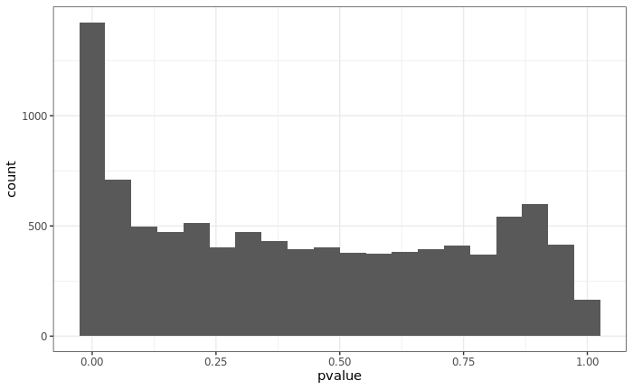

```r
ggplot(tests, aes(x = pvalue)) + geom_histogram(bins = 20) + theme_bw()
```

To see the large transcriptional shift we can use a volcano plot:

```
Using size for a discrete variable is not advised.
```

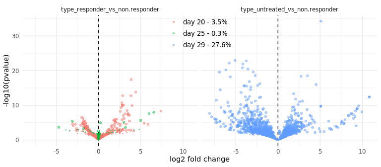

```r
day_labels <- sig_counts[order(day),
                         sprintf("day %d - %2.1f%%", day, 100 * ptr)]

ggplot(tests, aes(x = log2FoldChange, y = -log10(pvalue),
                        color = factor(day))) +
  geom_vline(xintercept = 0, lty = "dashed") +
  geom_point(aes(size = (padj < 0.05 & !is.na(padj))),
             alpha = 0.5, stroke = 0) +
  scale_size_discrete(range = c(1, 2)) + guides(size = "none") +
  facet_wrap(~ coefficient) +
  theme_minimal() + theme(legend.position = c(0.5, 0.9),
                     legend.background = element_blank(),
                     legend.key = element_blank(),
                     legend.text = element_text(size = 10)) +
  labs(x = "log2 fold change", color = "") +
  scale_color_discrete(labels = day_labels)
```

```r
fig_data[["Fig. 4B-C"]] <- tests
ggsave("figures/volcano_functional.png", height = 3.5, width = 8, dpi = 300)
```

Lets see the most prominent pathways in the significant hits.

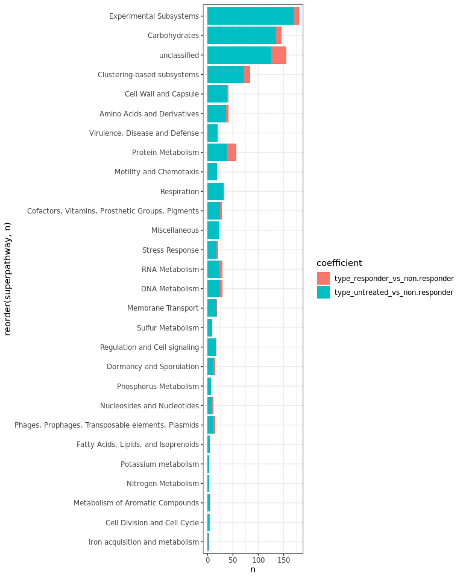

```r
sig <- tests[padj < 0.05]
cn <- sig[, .(n=.N, coef=median(log2FoldChange)), by = c("superpathway", "coefficient", "day")][order(day, -n)]
ggplot(cn, aes(x=n, y=reorder(superpathway, n), fill=coefficient)) + geom_bar(stat="identity", position="stack")
```

Lets have a look at some of the obvious pathways:

```r
library(viridis)
library(scales)
library(pheatmap)

pws <- idmap[sig$id, superpathway]
norm_counts <- t(mbtools::normalize(t(count_mat)))[, meta$day == 29]

keyword <- ""
selected <- norm_counts[sig[grepl(keyword, superpathway), id],]
signs <- sig[grepl(keyword, superpathway), table(sign(log2FoldChange))]
names(signs) <- c("higher in non-responders", "higer in untreated")
seed <- sig[grepl(keyword, superpathway), description]
selected <- as.data.frame(selected)
selected$description <- seed
fig_data[["Fig. 5A-E"]] <- selected
```

```r
keyword <- "Carbo"
selected <- norm_counts[sig[grepl(keyword, superpathway), id],]
signs <- sig[grepl(keyword, superpathway), table(sign(log2FoldChange))]
names(signs) <- c("higher in non-responders", "higer in untreated")
rownames(selected) <- stringr::str_trunc(sig[grepl(keyword, superpathway),
                                             description], 80)
anns <- data.frame(type = meta[day == 29, type])
cols <- list(type = hue_pal()(2))
names(cols$type) <- unique(anns$type)
rownames(anns) <- meta[day == 29, Sample]
pheatmap(log10(selected + 1), annotation_col = anns, annotation_colors = cols,
         color = viridis(128),
         filename = sprintf("figures/heatmap_%s.pdf", keyword),
         cellwidth = 10, cellheight = 10, legend_breaks = 0:6)

signs
```

```
higher in non-responders       higer in untreated
                      72                       74
```

[figure not shown]

```r
pheatmap(log10(selected + 1), annotation_col = anns, annotation_colors = cols,
         color = viridis(128), legend_breaks = 0:6)
```

You can vary the keyword on top to get different submodules.

## Pulling out particular function sets

We can also show particular sets of functions. For that let we will write a quick function to build up a merged count data set.

```r
tidy_counts <- function(ids, count_matrix, sample_data, function_groups) {
  cn <- as.data.table(count_matrix[ids, ])
  cn$id <- ids
  cn <- melt(cn, id.vars = "id", variable.name = "Sample", value.name = "reads")
  cn <- sample_data[cn, on = "Sample"]
  cn <- function_groups[cn, on = "id"]
  cn
}
```

We can now use that to pull out entire subsystems. Let us have a look at the Vancomycin tolerance locus that showed up in the significant results.

```r
vanc <- sig[grepl("Vancomycin", subpathway), id]
vanc_counts <- tidy_counts(vanc, norm_counts, meta, sig)
vanc_counts[, gene := stringr::str_match(description, "V.+")[, 1]]
vanc_counts
```

| id | description | superpathway | pathway | subpathway | baseMean | log2FoldChange | lfcSE | pvalue | padj | day | coefficient | Sample ID | Sample | RIN | concentration [ng/ul] | abundance [ng] | Comments | type | i.day | mouse | timepoint_cat | reads | gene |
| --- | --- | --- | --- | --- | --- | --- | --- | --- | --- | --- | --- | --- | --- | --- | --- | --- | --- | --- | --- | --- | --- | --- | --- |
| SS12783 | ABC transporter, ATP-binding protein Vex2 | Virulence, Disease and Defense | Resistance to antibiotics and toxic compounds | Streptococcus pneumoniae Vancomycin Tolerance Locus | 790.50697 | -5.086096 | 0.5049613 | 1.068153e-23 | 1.613445e-20 | 29 | type_untreated_vs_non.responder | 10 | A5D29 | 6.8 | 10 | 500 |  | non-responder | 29 | A5 | during | 709.141753 | Vex2 |
| SS12787 | Sensor histidine kinase VncS | Virulence, Disease and Defense | Resistance to antibiotics and toxic compounds | Streptococcus pneumoniae Vancomycin Tolerance Locus | 83.87502 | -4.155093 | 0.4318895 | 1.262184e-22 | 7.888653e-20 | 29 | type_untreated_vs_non.responder | 10 | A5D29 | 6.8 | 10 | 500 |  | non-responder | 29 | A5 | during | 104.409365 | VncS |
| SS12785 | ABC transporter membrane-spanning permease, Pep export, Vex3 | Virulence, Disease and Defense | Resistance to antibiotics and toxic compounds | Streptococcus pneumoniae Vancomycin Tolerance Locus | 345.91096 | -5.646992 | 0.6621388 | 5.730265e-19 | 1.279077e-16 | 29 | type_untreated_vs_non.responder | 10 | A5D29 | 6.8 | 10 | 500 |  | non-responder | 29 | A5 | during | 326.688535 | Vex3 |
| SS12788 | Two-component response regulator VncR | Virulence, Disease and Defense | Resistance to antibiotics and toxic compounds | Streptococcus pneumoniae Vancomycin Tolerance Locus | 156.19410 | -3.724539 | 0.5833300 | 3.159510e-12 | 2.820991e-10 | 29 | type_untreated_vs_non.responder | 10 | A5D29 | 6.8 | 10 | 500 |  | non-responder | 29 | A5 | during | 128.419881 | VncR |
| SS12784 | ABC transporter membrane-spanning permease, Pep export, Vex1 | Virulence, Disease and Defense | Resistance to antibiotics and toxic compounds | Streptococcus pneumoniae Vancomycin Tolerance Locus | 58.77982 | -6.159028 | 2.2190084 | 9.490516e-05 | 9.125496e-04 | 29 | type_untreated_vs_non.responder | 10 | A5D29 | 6.8 | 10 | 500 |  | non-responder | 29 | A5 | during | 50.983368 | Vex1 |
| SS12783 | ABC transporter, ATP-binding protein Vex2 | Virulence, Disease and Defense | Resistance to antibiotics and toxic compounds | Streptococcus pneumoniae Vancomycin Tolerance Locus | 790.50697 | -5.086096 | 0.5049613 | 1.068153e-23 | 1.613445e-20 | 29 | type_untreated_vs_non.responder | 17 | B1D29 | 5.2 | 17 | 850 |  | untreated | 29 | B1 | during | 109.154951 | Vex2 |
| SS12787 | Sensor histidine kinase VncS | Virulence, Disease and Defense | Resistance to antibiotics and toxic compounds | Streptococcus pneumoniae Vancomycin Tolerance Locus | 83.87502 | -4.155093 | 0.4318895 | 1.262184e-22 | 7.888653e-20 | 29 | type_untreated_vs_non.responder | 17 | B1D29 | 5.2 | 17 | 850 |  | untreated | 29 | B1 | during | 12.128328 | VncS |
| SS12785 | ABC transporter membrane-spanning permease, Pep export, Vex3 | Virulence, Disease and Defense | Resistance to antibiotics and toxic compounds | Streptococcus pneumoniae Vancomycin Tolerance Locus | 345.91096 | -5.646992 | 0.6621388 | 5.730265e-19 | 1.279077e-16 | 29 | type_untreated_vs_non.responder | 17 | B1D29 | 5.2 | 17 | 850 |  | untreated | 29 | B1 | during | 43.122943 | Vex3 |
| SS12788 | Two-component response regulator VncR | Virulence, Disease and Defense | Resistance to antibiotics and toxic compounds | Streptococcus pneumoniae Vancomycin Tolerance Locus | 156.19410 | -3.724539 | 0.5833300 | 3.159510e-12 | 2.820991e-10 | 29 | type_untreated_vs_non.responder | 17 | B1D29 | 5.2 | 17 | 850 |  | untreated | 29 | B1 | during | 21.561472 | VncR |
| SS12784 | ABC transporter membrane-spanning permease, Pep export, Vex1 | Virulence, Disease and Defense | Resistance to antibiotics and toxic compounds | Streptococcus pneumoniae Vancomycin Tolerance Locus | 58.77982 | -6.159028 | 2.2190084 | 9.490516e-05 | 9.125496e-04 | 29 | type_untreated_vs_non.responder | 17 | B1D29 | 5.2 | 17 | 850 |  | untreated | 29 | B1 | during | 6.737960 | Vex1 |

[output cut: 25 more lines]

We can use that tidy data set to easily visualize a set of genes at once:

```r
pl <- ggplot(vanc_counts, aes(x = gene, y = reads + 0.5, col = type)) +
  geom_jitter(width = 0.2) + scale_y_log10() +
  stat_summary(fun.ymax = mean, fun.ymin = mean, fun.y = mean,
               geom = "crossbar", width = 0.3) +
  theme_bw() + labs(x = "vancomycin tolerance locus", y = "normalized reads")
```

```
`fun.y` is deprecated. Use `fun` instead.`fun.ymin` is deprecated. Use `fun.min` instead.`fun.ymax` is deprecated. Use `fun.max` instead.
```

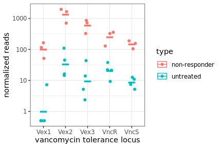

```r
ggsave("figures/vancomycin_locus.svg", width = 4.5, height = 3)
pl
```

```r
acoa_synth <- sig[grepl("CoA synthase", description), id]
as_counts <- tidy_counts(acoa_synth, norm_counts, meta, sig)

pl <- ggplot(as_counts, aes(x = id, y = reads + 0.5, col = type)) +
  geom_jitter(width = 0.2) + scale_y_log10() +
  stat_summary(fun.ymax = mean, fun.ymin = mean, fun.y = mean,
               geom = "crossbar", width = 0.3) +
  theme_bw() + labs(x = "Acetyl-CoA synthase", y = "normalized reads")
```

```
`fun.y` is deprecated. Use `fun` instead.`fun.ymin` is deprecated. Use `fun.min` instead.`fun.ymax` is deprecated. Use `fun.max` instead.
```

[figure not shown]

```r
ggsave("figures/acoa_synthase.svg", width = 4, height = 3)
pl
```

Finally we save the raw figure data.

```r
fig_data <- lapply(fig_data, as.data.frame)
openxlsx::write.xlsx(fig_data[sort(names(fig_data))], "data/TableS1.xlsx")
```